# ie48b-hw1

Mehmet Akif Taşcıoğlu

# Gesture Recognition

## Introduction

In this assignment, the x, y and z coordinates of the waves were given separately and I tried to manipulate and visualize a multivariate time series data.After reading the data, some manipulations are executed like melt function to see the data properly.I found acceleration values and i calculate velocity and location values of every point by using cumsum function.I visualized waves in 3d by using scatterplot3d function.

```r
data_path= 'C:/Users/User/Desktop/ie48b/hw1/data/uWaveGestureLibrary_X_TRAIN'
x_train=fread(data_path)
head(x_train)
```

```
##    V1           V2           V3           V4           V5           V6
## 1:  6 -0.304243210 -0.304243210 -0.304243210 -0.304243210 -0.304243210
## 2:  5  1.627311100  1.627311100  1.627311100  1.627311100  1.627311100
## 3:  5  0.661276530  0.661276530  0.661276530  0.661276530  0.661276530
## 4:  3  0.005184784  0.005184784  0.005184784  0.005184784  0.005184784
## 5:  4  1.286197800  1.286197800  1.286197800  1.286197800  1.286197800
## 6:  8 -0.479252460 -0.479252460 -0.479252460 -0.479252460 -0.479252460
##              V7           V8           V9          V10          V11
## 1: -0.304243210 -0.304243210 -0.304243210 -0.304243210 -0.304243210
## 2:  1.627311100  1.627311100  1.627311100  1.627311100  1.627311100
## 3:  0.661276530  0.661276530  0.661276530  0.661276530  0.661276530
## 4:  0.005184784  0.005184784  0.005184784  0.005184784  0.005184784
## 5:  1.286197800  1.286197800  1.286197800  1.286197800  1.286197800
## 6: -0.479252460 -0.479252460 -0.479252460 -0.479252460 -0.479252460
##             V12          V13          V14          V15          V16
```

[output cut: 342 more lines]

```r
data_path= 'C:/Users/User/Desktop/ie48b/hw1/data/uWaveGestureLibrary_Y_TRAIN'
y_train=fread(data_path)
data_path= 'C:/Users/User/Desktop/ie48b/hw1/data/uWaveGestureLibrary_Z_TRAIN'
z_train=fread(data_path)
```

## Data Manipulation

```r
# first add id variable (data.table notation)
# and rename column name "V1" with "class"
#sort based on class first
# for x axes
setnames(x_train,'V1','class')
x_train=x_train[order(class)]
x_train[,class:=as.character(class)]
x_train[,id:=1:.N]
head(x_train)
```

```
##    class         V2         V3         V4         V5         V6         V7
## 1:     1 -0.7914472 -0.7914472 -0.7958727 -0.8100650 -0.8492300 -0.9034648
## 2:     1 -0.4496024 -0.4496024 -0.4496024 -0.4496024 -0.4496024 -0.4496024
## 3:     1 -0.1874689 -0.1874689 -0.1874689 -0.1874689 -0.1874689 -0.1874689
## 4:     1  0.3014817  0.3014817  0.3014817  0.3014817  0.3014817  0.3014817
## 5:     1  0.1632022  0.1632022  0.1632022  0.1632022  0.1632022  0.1632022
## 6:     1 -0.9319900 -0.9319900 -0.9319900 -0.9319900 -0.9319900 -0.9319900
##            V8         V9        V10        V11        V12        V13        V14
## 1: -0.9311463 -0.9506034 -0.9506034 -0.9506034 -0.9506034 -0.9506034 -0.9506034
## 2: -0.4496024 -0.4496024 -0.4496024 -0.4496024 -0.4496024 -0.4496024 -0.4496024
## 3: -0.1874689 -0.1874689 -0.1874689 -0.1874689 -0.1874689 -0.1874689 -0.1874689
## 4:  0.3014817  0.3014817  0.3014817  0.3014817  0.3014817  0.3014817  0.3014817
## 5:  0.1632022  0.1632022  0.1632022  0.1632022  0.1632022  0.1632022  0.1632022
## 6: -0.9319900 -0.9319900 -0.9319900 -0.9319900 -0.9319900 -0.9319900 -0.9319900
##           V15        V16        V17        V18        V19        V20        V21
```

[output cut: 328 more lines]

```r
#for y axes
setnames(y_train,'V1','class')
y_train=y_train[order(class)]
y_train[,class:=as.character(class)]
y_train[,id:=1:.N]
head(y_train)
```

```
##    class         V2         V3         V4         V5         V6         V7
## 1:     1 -1.9599838 -1.9599838 -1.9566005 -1.9457505 -1.9158091 -1.8743468
## 2:     1 -1.9712004 -1.9712004 -1.9712004 -1.9712004 -1.9712004 -1.9712004
## 3:     1 -1.2364488 -1.2364488 -1.2364488 -1.2364488 -1.2364488 -1.2364488
## 4:     1 -1.4935131 -1.4935131 -1.4935131 -1.4935131 -1.4935131 -1.4935131
## 5:     1 -0.6158814 -0.6158814 -0.6158814 -0.6158814 -0.6158814 -0.6158814
## 6:     1 -1.6753297 -1.6753297 -1.6753297 -1.6753297 -1.6753297 -1.6753297
##            V8         V9        V10        V11        V12        V13        V14
## 1: -1.8531844 -1.8383095 -1.8383095 -1.8383095 -1.8383095 -1.8383095 -1.8383095
## 2: -1.9712004 -1.9712004 -1.9712004 -1.9712004 -1.9712004 -1.9712004 -1.9712004
## 3: -1.2364488 -1.2364488 -1.2364488 -1.2364488 -1.2364488 -1.2364488 -1.2364488
## 4: -1.4935131 -1.4935131 -1.4935131 -1.4935131 -1.4935131 -1.4935131 -1.4935131
## 5: -0.6158814 -0.6158814 -0.6158814 -0.6158814 -0.6158814 -0.6158814 -0.6158814
## 6: -1.6753297 -1.6753297 -1.6753297 -1.6753297 -1.6753297 -1.6753297 -1.6753297
##           V15        V16        V17        V18        V19        V20        V21
```

[output cut: 321 more lines]

```r
#for z axes
setnames(z_train,'V1','class')
z_train=z_train[order(class)]
z_train[,class:=as.character(class)]
z_train[,id:=1:.N]
head(z_train)
```

```
##    class         V2         V3         V4         V5         V6         V7
## 1:     1 -0.2490781 -0.2490781 -0.2514390 -0.2590101 -0.2799033 -0.3088358
## 2:     1 -1.2897498 -1.2897498 -1.2897498 -1.2897498 -1.2897498 -1.2897498
## 3:     1 -0.8108461 -0.8108461 -0.8108461 -0.8108461 -0.8108461 -0.8108461
## 4:     1 -1.1472344 -1.1472344 -1.1472344 -1.1472344 -1.1472344 -1.1472344
## 5:     1 -1.3271478 -1.3271478 -1.3271478 -1.3271478 -1.3271478 -1.3271478
## 6:     1 -1.8033172 -1.8033172 -1.8033172 -1.8033172 -1.8033172 -1.8033172
##            V8         V9        V10        V11        V12        V13        V14
## 1: -0.3236030 -0.3339827 -0.3339827 -0.3339827 -0.3339827 -0.3339827 -0.3339827
## 2: -1.2897498 -1.2897498 -1.2897498 -1.2897498 -1.2897498 -1.2897498 -1.2897498
## 3: -0.8108461 -0.8108461 -0.8108461 -0.8108461 -0.8108461 -0.8108461 -0.8108461
## 4: -1.1472344 -1.1472344 -1.1472344 -1.1472344 -1.1472344 -1.1472344 -1.1472344
## 5: -1.3271478 -1.3271478 -1.3271478 -1.3271478 -1.3271478 -1.3271478 -1.3271478
## 6: -1.8033172 -1.8033172 -1.8033172 -1.8033172 -1.8033172 -1.8033172 -1.8033172
##           V15        V16        V17        V18        V19        V20        V21
```

[output cut: 328 more lines]

```r
# melt the data for long format

x_train=melt(x_train,id.vars=c('id','class'))
head(x_train)
```

```
##    id class variable      value
## 1:  1     1       V2 -0.7914472
## 2:  2     1       V2 -0.4496024
## 3:  3     1       V2 -0.1874689
## 4:  4     1       V2  0.3014817
## 5:  5     1       V2  0.1632022
## 6:  6     1       V2 -0.9319900
```

```r
x_train[,time:=as.numeric(gsub("\\D", "", variable))-1]
head(x_train)
```

```
##    id class variable      value time
## 1:  1     1       V2 -0.7914472    1
## 2:  2     1       V2 -0.4496024    1
## 3:  3     1       V2 -0.1874689    1
## 4:  4     1       V2  0.3014817    1
## 5:  5     1       V2  0.1632022    1
## 6:  6     1       V2 -0.9319900    1
```

```r
# remove variable
x_train=x_train[,list(id,class,time,value)]
x_train=x_train[order(id,time)]
head(x_train)
```

```
##    id class time      value
## 1:  1     1    1 -0.7914472
## 2:  1     1    2 -0.7914472
## 3:  1     1    3 -0.7958727
## 4:  1     1    4 -0.8100650
## 5:  1     1    5 -0.8492300
## 6:  1     1    6 -0.9034648
```

```r
# Same manipulations for the axes Y

y_train=melt(y_train,id.vars=c('id','class'))
y_train[,time:=as.numeric(gsub("\\D", "", variable))-1]
# remove variable
y_train=y_train[,list(id,class,time,value)]
y_train=y_train[order(id,time)]
head(y_train)
```

```
##    id class time     value
## 1:  1     1    1 -1.959984
## 2:  1     1    2 -1.959984
## 3:  1     1    3 -1.956600
## 4:  1     1    4 -1.945750
## 5:  1     1    5 -1.915809
## 6:  1     1    6 -1.874347
```

```r
# Same manipulations for the axes Z

z_train=melt(z_train,id.vars=c('id','class'))
z_train[,time:=as.numeric(gsub("\\D", "", variable))-1]
# remove variable
z_train=z_train[,list(id,class,time,value)]
z_train=z_train[order(id,time)]
head(z_train)
```

```
##    id class time      value
## 1:  1     1    1 -0.2490781
## 2:  1     1    2 -0.2490781
## 3:  1     1    3 -0.2514390
## 4:  1     1    4 -0.2590101
## 5:  1     1    5 -0.2799033
## 6:  1     1    6 -0.3088358
```

```r
# Merging the axes
xyz_train =x_train
setnames(xyz_train,'value','acceleration_x')
xyz_train$acceleration_y = y_train$value
xyz_train$acceleration_z = z_train$value
head(xyz_train)
```

```
##    id class time acceleration_x acceleration_y acceleration_z
## 1:  1     1    1     -0.7914472      -1.959984     -0.2490781
## 2:  1     1    2     -0.7914472      -1.959984     -0.2490781
## 3:  1     1    3     -0.7958727      -1.956600     -0.2514390
## 4:  1     1    4     -0.8100650      -1.945750     -0.2590101
## 5:  1     1    5     -0.8492300      -1.915809     -0.2799033
## 6:  1     1    6     -0.9034648      -1.874347     -0.3088358
```

```r
# Adding the speed and location information for all axes


xyz_train[,speed_x:=cumsum(acceleration_x),by=id]

xyz_train[,speed_y:=cumsum(acceleration_y),by=id]

xyz_train[,speed_z:=cumsum(acceleration_z),by=id]


xyz_train[,location_x:=cumsum(speed_x),by=id]

xyz_train[,location_y:=cumsum(speed_y),by=id]

xyz_train[,location_z:=cumsum(speed_z),by=id]
head(xyz_train)
```

```
##    id class time acceleration_x acceleration_y acceleration_z    speed_x
## 1:  1     1    1     -0.7914472      -1.959984     -0.2490781 -0.7914472
## 2:  1     1    2     -0.7914472      -1.959984     -0.2490781 -1.5828944
## 3:  1     1    3     -0.7958727      -1.956600     -0.2514390 -2.3787671
## 4:  1     1    4     -0.8100650      -1.945750     -0.2590101 -3.1888321
## 5:  1     1    5     -0.8492300      -1.915809     -0.2799033 -4.0380621
## 6:  1     1    6     -0.9034648      -1.874347     -0.3088358 -4.9415269
##       speed_y    speed_z  location_x location_y location_z
## 1:  -1.959984 -0.2490781  -0.7914472  -1.959984 -0.2490781
## 2:  -3.919968 -0.4981562  -2.3743415  -5.879951 -0.7472342
## 3:  -5.876568 -0.7495951  -4.7531086 -11.756519 -1.4968294
## 4:  -7.822319 -1.0086052  -7.9419407 -19.578838 -2.5054346
## 5:  -9.738128 -1.2885085 -11.9800028 -29.316966 -3.7939431
## 6: -11.612474 -1.5973444 -16.9215298 -40.929440 -5.3912875
```

# PART 1

## 3D Scatter Plots

I chose randomly a wave from each class.

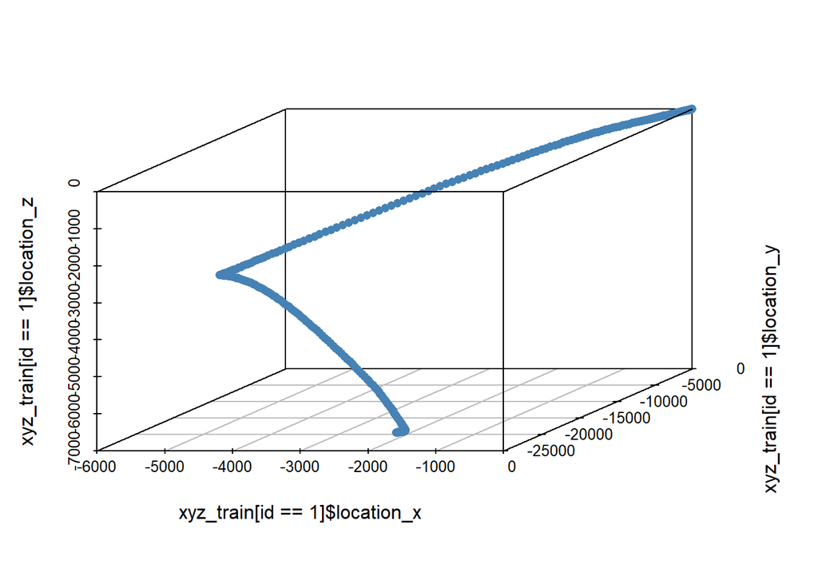

```r
# Class 1-id 1
scatterplot3d(xyz_train[id==1]$location_x,xyz_train[id==1]$location_y,xyz_train[id==1]$location_z, pch = 16, color="steelblue")
```

```r
xyz_train[id==1]$class
```

[output not shown]

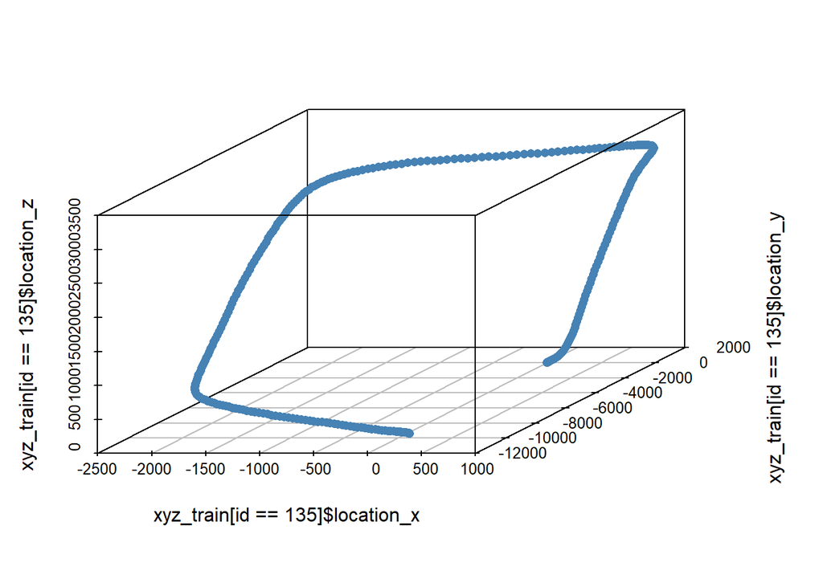

```r
#Class 2 - id 135
scatterplot3d(xyz_train[id==135]$location_x,xyz_train[id==135]$location_y,xyz_train[id==135]$location_z, pch = 16, color="steelblue")
```

```r
xyz_train[id==135]$class
```

[output not shown]

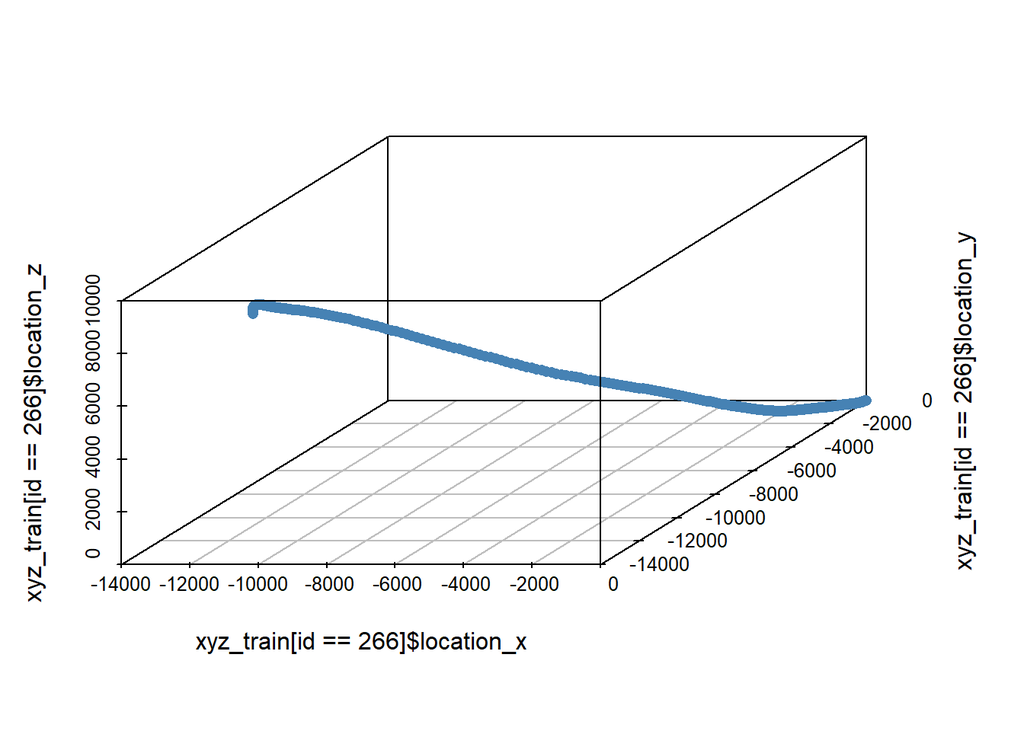

```r
# Class 3 - id 266
scatterplot3d(xyz_train[id==266]$location_x,xyz_train[id==266]$location_y,xyz_train[id==266]$location_z, pch = 16, color="steelblue")
```

```r
xyz_train[id==266]$class
```

[output not shown]

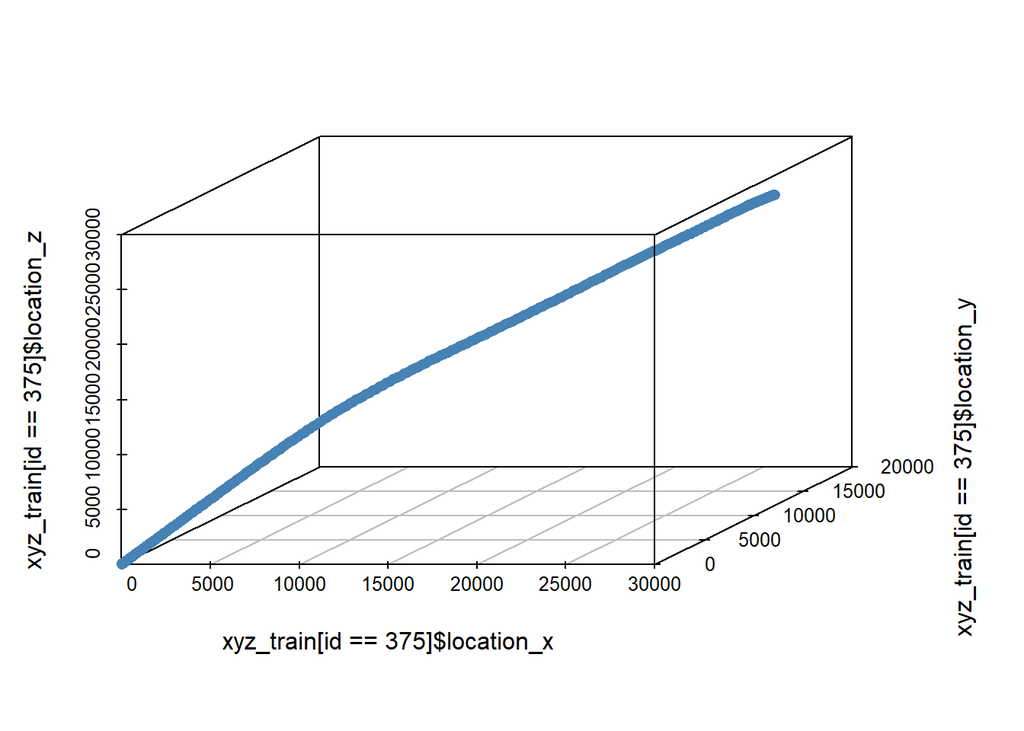

```r
# Class 4 - id 375
scatterplot3d(xyz_train[id==375]$location_x,xyz_train[id==375]$location_y,xyz_train[id==375]$location_z, pch = 16, color="steelblue")
```

```r
xyz_train[id==375]$class
```

[output not shown]

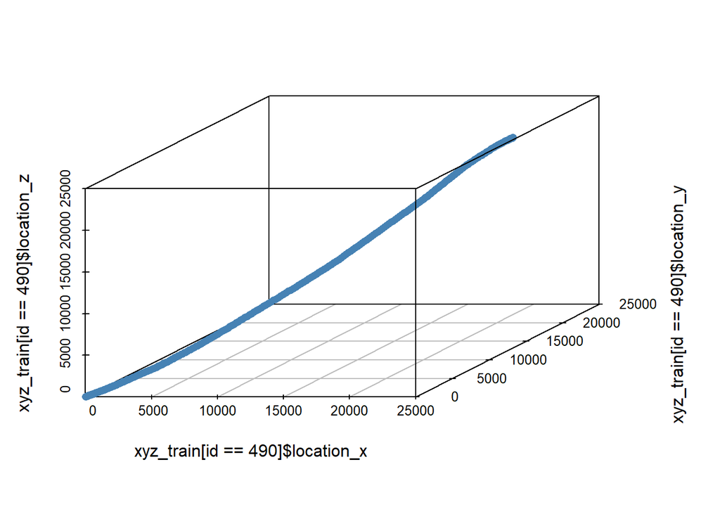

```r
#Class 5 - id 490
scatterplot3d(xyz_train[id==490]$location_x,xyz_train[id==490]$location_y,xyz_train[id==490]$location_z, pch = 16, color="steelblue")
```

```r
xyz_train[id==490]$class
```

[output not shown]

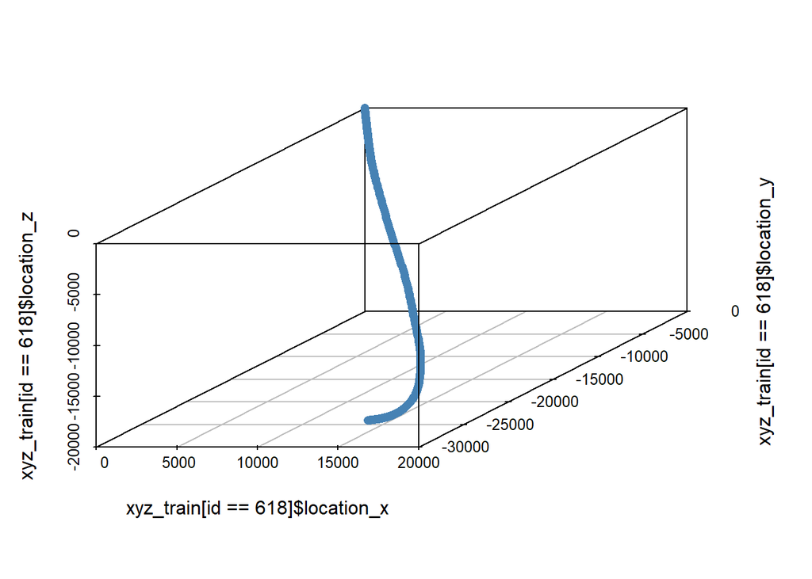

```r
#Class 6 - id 618
scatterplot3d(xyz_train[id==618]$location_x,xyz_train[id==618]$location_y,xyz_train[id==618]$location_z, pch = 16, color="steelblue")
```

```r
xyz_train[id==618]$class
```

[output not shown]

sixth image is a vertical straight line in gesture vocabulary , but in this plot ,it goes diagonally and bends like a curve.

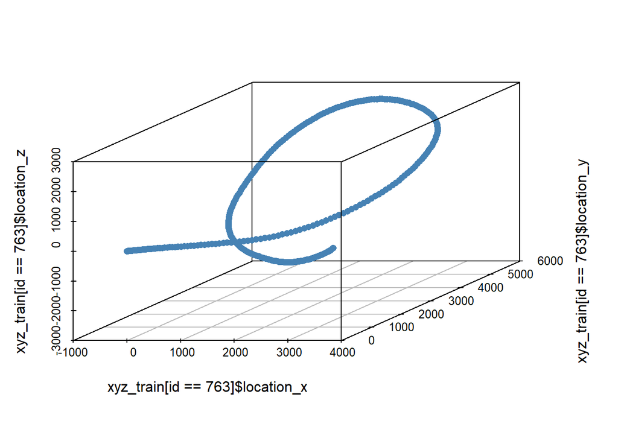

```r
#Class 7 - id 763
scatterplot3d(xyz_train[id==763]$location_x,xyz_train[id==763]$location_y,xyz_train[id==763]$location_z, pch = 16, color="steelblue")
```

```r
xyz_train[id==763]$class
```

[output not shown]

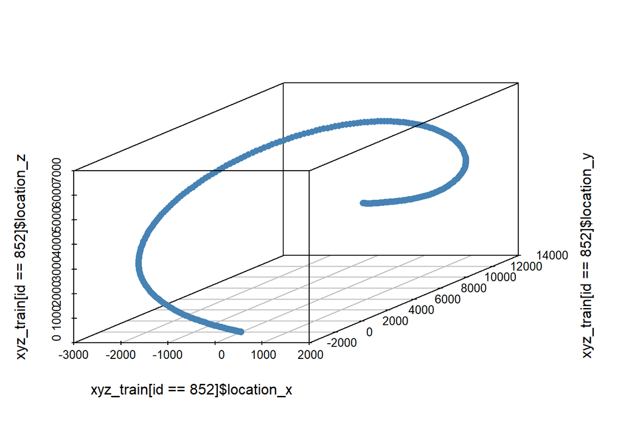

```r
#Class 8 - id 852
scatterplot3d(xyz_train[id==852]$location_x,xyz_train[id==852]$location_y,xyz_train[id==852]$location_z, pch = 16, color="steelblue")
```

```r
xyz_train[id==852]$class
```

[output not shown]

Plots 1, 2, 7 and 8 are similar to the shapes in gesture vocabulary.

# PART 2 -Alternative Time Series Representations

## Distance to Orijin Representation

For my first representation, I calculated the euclidean distance of each point from the origin and added this information to the columns for every time step.Then I found the average distances of the points for each class.

```r
distance<- function(x_coor,y_coor,z_coor){
  d=sqrt((x_coor-0)^2+(y_coor-0)^2+(z_coor-0)^2)
  return(d)
}
xyz_train[,distance_to_orijin:=distance(location_x,location_y,location_z),by=id]
class1_distance_to_orijin=mean(xyz_train[class==1]$distance_to_orijin)
class2_distance_to_orijin=mean(xyz_train[class==2]$distance_to_orijin)
class3_distance_to_orijin=mean(xyz_train[class==3]$distance_to_orijin)
class4_distance_to_orijin=mean(xyz_train[class==4]$distance_to_orijin)
class5_distance_to_orijin=mean(xyz_train[class==5]$distance_to_orijin)
class6_distance_to_orijin=mean(xyz_train[class==6]$distance_to_orijin)
class7_distance_to_orijin=mean(xyz_train[class==7]$distance_to_orijin)
class8_distance_to_orijin=mean(xyz_train[class==8]$distance_to_orijin)
```

```r
dt<-c(class1_distance_to_orijin,class2_distance_to_orijin,class3_distance_to_orijin,class4_distance_to_orijin,class5_distance_to_orijin,class6_distance_to_orijin,class7_distance_to_orijin,class8_distance_to_orijin)
dt
```

```
## [1] 14696.415  5333.484 15322.282 16093.676 18231.860 18117.222  7450.550
## [8]  6591.756
```

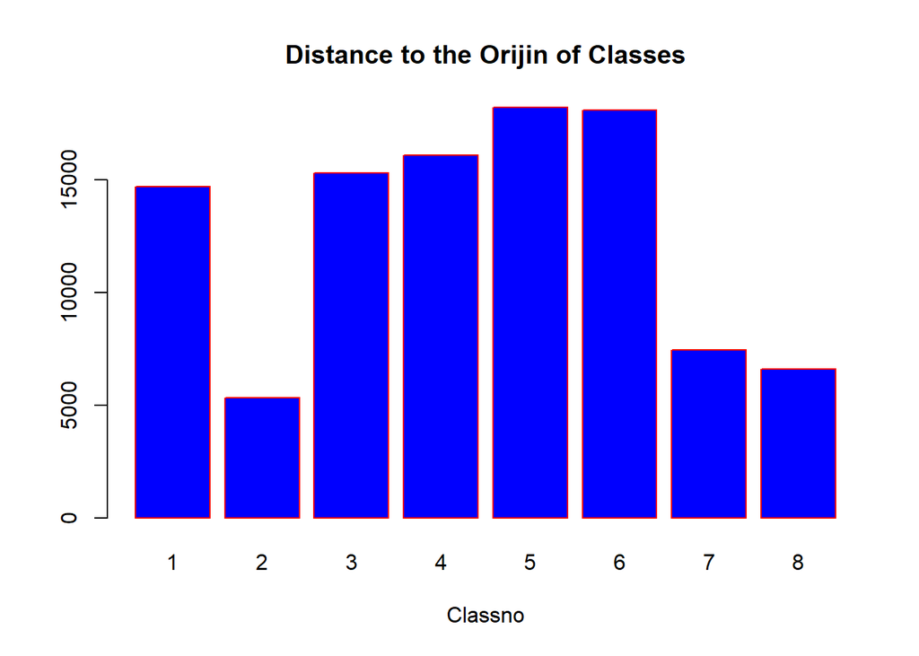

```r
classno<-c(1:8)
barplot(dt,names.arg=classno,xlab="Classno",main="Distance to the Orijin of Classes",col="blue",border="red")
```

Waves in the 5th and 6th classes are, on average, more distant from the origin.Waves in the 2nd, 7th and 8th classes consist of points closer to the origin on average. This is a very logical output.Because in pdf As the gesture vocabulary figures show, the waves in the 3,4,5,6th classes are waves that go in a continuous direction, so their distance from the origin is high, and the reason why they are higher in 5 and 6 is the movements of the waves in the z axis. The waves in the 2nd, 7th and 8th classes are curved waves, so their distance from the origin is lower.

## Individual model representation

I used an autogressive model of lag 2 for x,y and z coordinate time series.

```r
ar_xyz_train=copy(xyz_train)
ar_xyz_train=ar_xyz_train[order(id,time)]
ar_xyz_train[,lag1_x:=shift(location_x,1),by=list(id)]
ar_xyz_train[,lag2_x:=shift(location_x,2),by=list(id)]
ar_xyz_train[,lag1_y:=shift(location_y,1),by=list(id)]
ar_xyz_train[,lag2_y:=shift(location_y,2),by=list(id)]
ar_xyz_train[,lag1_z:=shift(location_z,1),by=list(id)]
ar_xyz_train[,lag2_z:=shift(location_z,2),by=list(id)]

head(ar_xyz_train)
```

```
##    id class time acceleration_x acceleration_y acceleration_z    speed_x
## 1:  1     1    1     -0.7914472      -1.959984     -0.2490781 -0.7914472
## 2:  1     1    2     -0.7914472      -1.959984     -0.2490781 -1.5828944
## 3:  1     1    3     -0.7958727      -1.956600     -0.2514390 -2.3787671
## 4:  1     1    4     -0.8100650      -1.945750     -0.2590101 -3.1888321
## 5:  1     1    5     -0.8492300      -1.915809     -0.2799033 -4.0380621
## 6:  1     1    6     -0.9034648      -1.874347     -0.3088358 -4.9415269
##       speed_y    speed_z  location_x location_y location_z distance_to_orijin
## 1:  -1.959984 -0.2490781  -0.7914472  -1.959984 -0.2490781           2.128371
## 2:  -3.919968 -0.4981562  -2.3743415  -5.879951 -0.7472342           6.385114
## 3:  -5.876568 -0.7495951  -4.7531086 -11.756519 -1.4968294          12.769036
## 4:  -7.822319 -1.0086052  -7.9419407 -19.578838 -2.5054346          21.276337
## 5:  -9.738128 -1.2885085 -11.9800028 -29.316966 -3.7939431          31.896692
## 6: -11.612474 -1.5973444 -16.9215298 -40.929440 -5.3912875          44.616401
##         lag1_x     lag2_x     lag1_y     lag2_y     lag1_z     lag2_z
## 1:          NA         NA         NA         NA         NA         NA
## 2:  -0.7914472         NA  -1.959984         NA -0.2490781         NA
## 3:  -2.3743415 -0.7914472  -5.879951  -1.959984 -0.7472342 -0.2490781
## 4:  -4.7531086 -2.3743415 -11.756519  -5.879951 -1.4968294 -0.7472342
## 5:  -7.9419407 -4.7531086 -19.578838 -11.756519 -2.5054346 -1.4968294
## 6: -11.9800028 -7.9419407 -29.316966 -19.578838 -3.7939431 -2.5054346
```

```r
series_id=unique(ar_xyz_train$id)

fit_ar2_x=function(dat){
    fit_x=lm(location_x~lag1_x+lag2_x,dat)
    return(data.frame(t(coef(fit_x))))
}
fit_ar2_y=function(dat){
    fit_y=lm(location_y~lag1_y+lag2_y,dat)
    return(data.frame(t(coef(fit_y))))
}
fit_ar2_z=function(dat){
    fit_z=lm(location_z~lag1_z+lag2_z,dat)
    return(data.frame(t(coef(fit_z))))
}
fitted_coef_x=lapply(series_id,function(x) fit_ar2_x(ar_xyz_train[id==x]))
fitted_coef_y=lapply(series_id,function(y) fit_ar2_y(ar_xyz_train[id==y]))
fitted_coef_z=lapply(series_id,function(z) fit_ar2_z(ar_xyz_train[id==z]))

coef_dt_x=rbindlist(fitted_coef_x)
coef_dt_y=rbindlist(fitted_coef_y)
coef_dt_z=rbindlist(fitted_coef_z)

head(coef_dt_x)
```

```
##    X.Intercept.   lag1_x     lag2_x
## 1:   -1.4727362 1.995253 -0.9957569
## 2:    0.2405608 2.007370 -1.0075834
## 3:    0.2605330 2.003429 -1.0036664
## 4:    0.6527754 1.998588 -0.9987479
## 5:   -0.2526508 2.003568 -1.0041588
## 6:   -1.8341848 1.991675 -0.9919887
```

```r
head(coef_dt_y)
```

```
##    X.Intercept.   lag1_y     lag2_y
## 1:   -2.2217499 1.990729 -0.9908522
## 2:   -2.1082745 1.993142 -0.9932512
## 3:   -1.7057580 1.994594 -0.9947060
## 4:   -1.8029859 1.991345 -0.9914687
## 5:   -0.9573037 2.001409 -1.0015131
## 6:   -1.7373955 1.996401 -0.9965036
```

```r
head(coef_dt_z)
```

```
##    X.Intercept.   lag1_z     lag2_z
## 1:   -0.6686476 1.997481 -0.9976545
## 2:   -1.3177676 1.993012 -0.9932039
## 3:   -1.5370083 1.992113 -0.9922937
## 4:   -2.0897039 1.989055 -0.9893641
## 5:   -1.1766335 1.997886 -0.9979903
## 6:   -2.0553587 1.984864 -0.9850670
```

```r
coef_dt_x[,id:=series_id]
coef_dt_y[,id:=series_id]
coef_dt_z[,id:=series_id]
coef_dt_x=merge(coef_dt_x,x_train[,list(id,class)],by='id')
coef_dt_y=merge(coef_dt_y,y_train[,list(id,class)],by='id')
coef_dt_z=merge(coef_dt_z,z_train[,list(id,class)],by='id')
head(coef_dt_x)
```

```
##    id X.Intercept.   lag1_x     lag2_x class
## 1:  1    -1.472736 1.995253 -0.9957569     1
## 2:  1    -1.472736 1.995253 -0.9957569     1
## 3:  1    -1.472736 1.995253 -0.9957569     1
## 4:  1    -1.472736 1.995253 -0.9957569     1
## 5:  1    -1.472736 1.995253 -0.9957569     1
## 6:  1    -1.472736 1.995253 -0.9957569     1
```

```r
head(coef_dt_y)
```

```
##    id X.Intercept.   lag1_y     lag2_y class
## 1:  1     -2.22175 1.990729 -0.9908522     1
## 2:  1     -2.22175 1.990729 -0.9908522     1
## 3:  1     -2.22175 1.990729 -0.9908522     1
## 4:  1     -2.22175 1.990729 -0.9908522     1
## 5:  1     -2.22175 1.990729 -0.9908522     1
## 6:  1     -2.22175 1.990729 -0.9908522     1
```

```r
head(coef_dt_z)
```

```
##    id X.Intercept.   lag1_z     lag2_z class
## 1:  1   -0.6686476 1.997481 -0.9976545     1
## 2:  1   -0.6686476 1.997481 -0.9976545     1
## 3:  1   -0.6686476 1.997481 -0.9976545     1
## 4:  1   -0.6686476 1.997481 -0.9976545     1
## 5:  1   -0.6686476 1.997481 -0.9976545     1
## 6:  1   -0.6686476 1.997481 -0.9976545     1
```

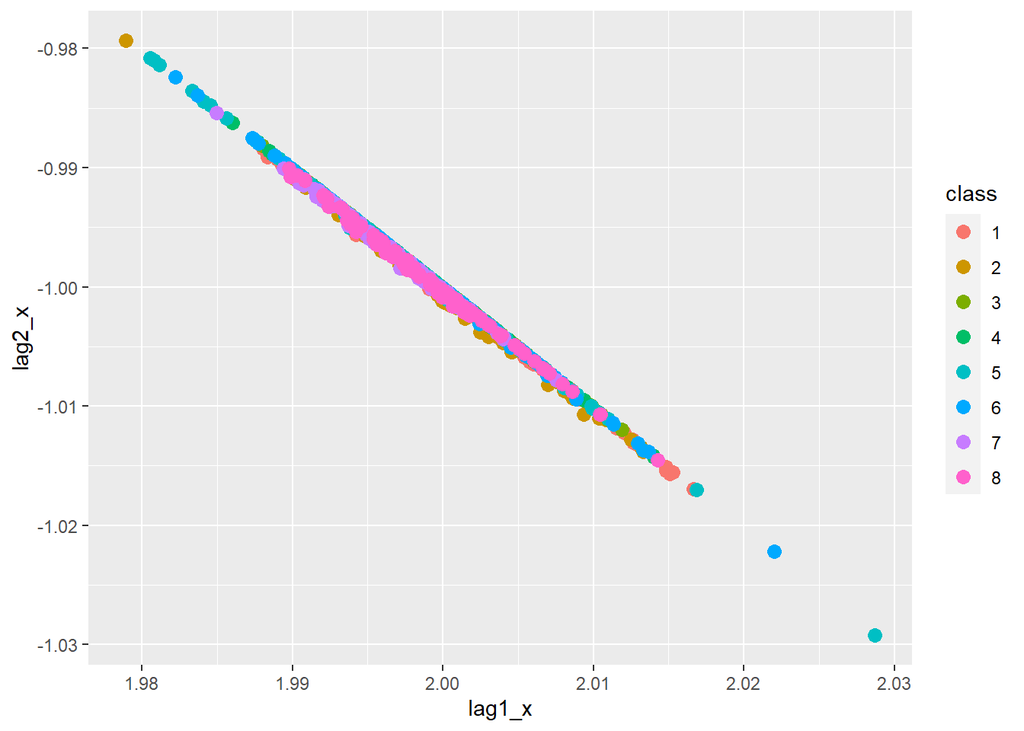

```r
ggplot(coef_dt_x,aes(x=lag1_x,y=lag2_x,color=class)) + geom_point(size = 3)
```

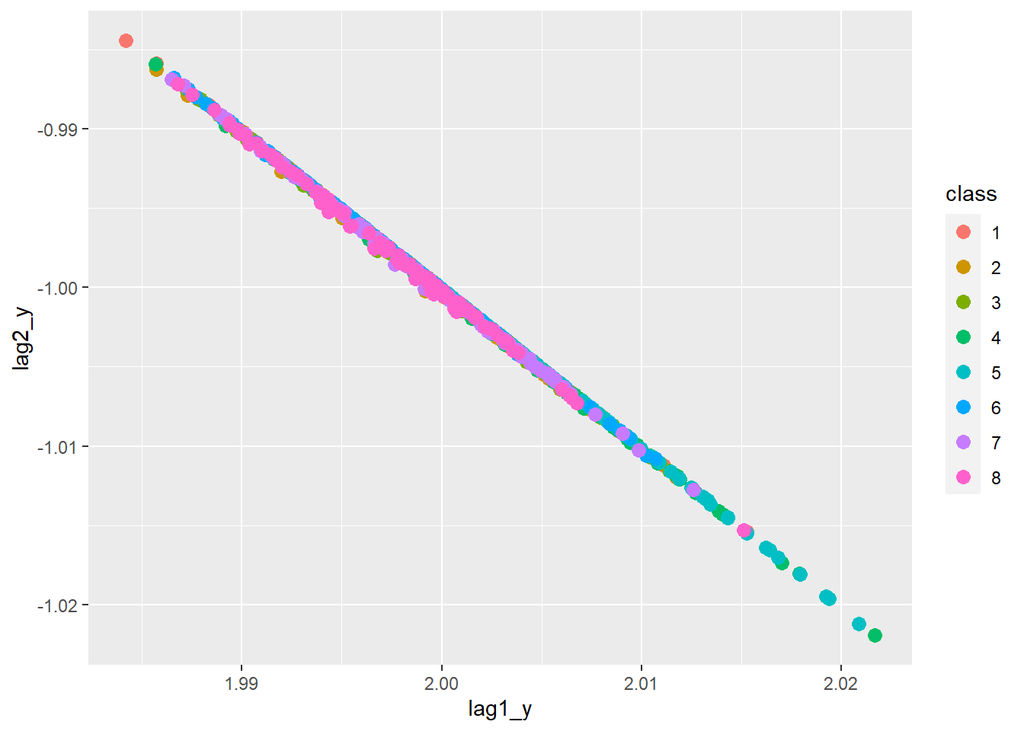

```r
ggplot(coef_dt_y,aes(x=lag1_y,y=lag2_y,color=class)) + geom_point(size = 3)
```

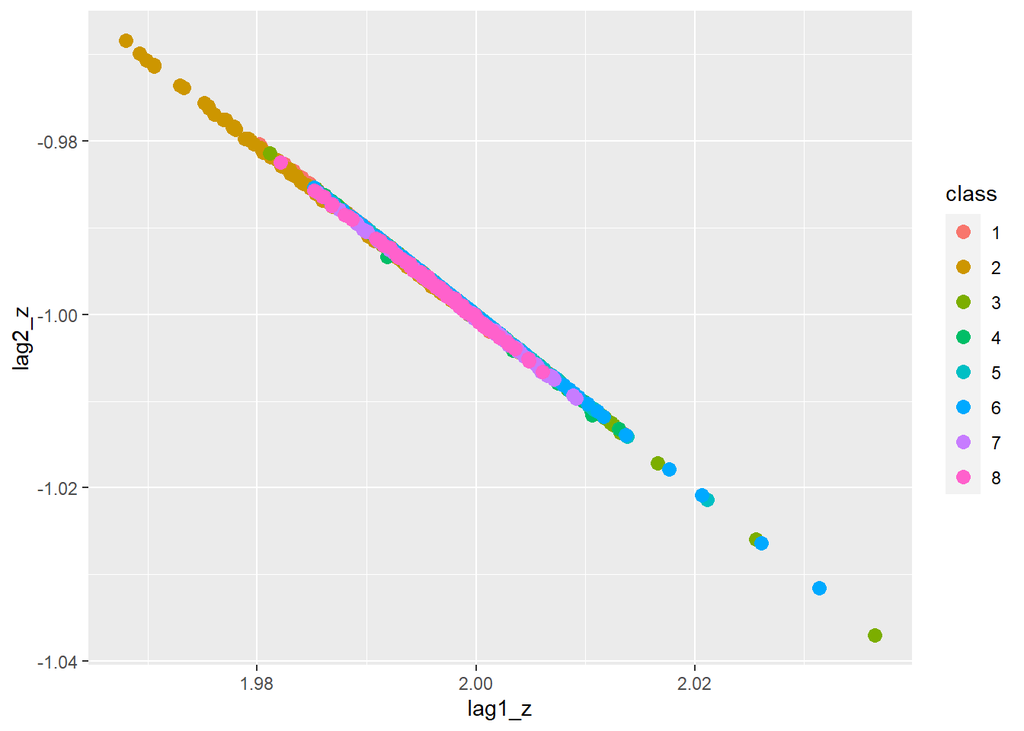

```r
ggplot(coef_dt_z,aes(x=lag1_z,y=lag2_z,color=class)) + geom_point(size = 3)
```

## Conclusion

To compare both representations, I would prefer the distance method to the orijin because it gives more information and detail about wave classes.